# Score-level path model: reference report

Planted chain view0 - view1 - view2, outcome from view2's first latent, two covariates leaking into every view (strength 0.8; removed by the confound sink at fit time and partialled out again as nuisance). Method `simlr`, k = 3, n = 500 (train 350, held-out 150), B = 5000 Freedman-Lane sweeps on the held-out rows, seed 0. Scores source: `latents`.

## 1. Fitted path model (hypothesis: chain + outcome edge; conditioning on parents)

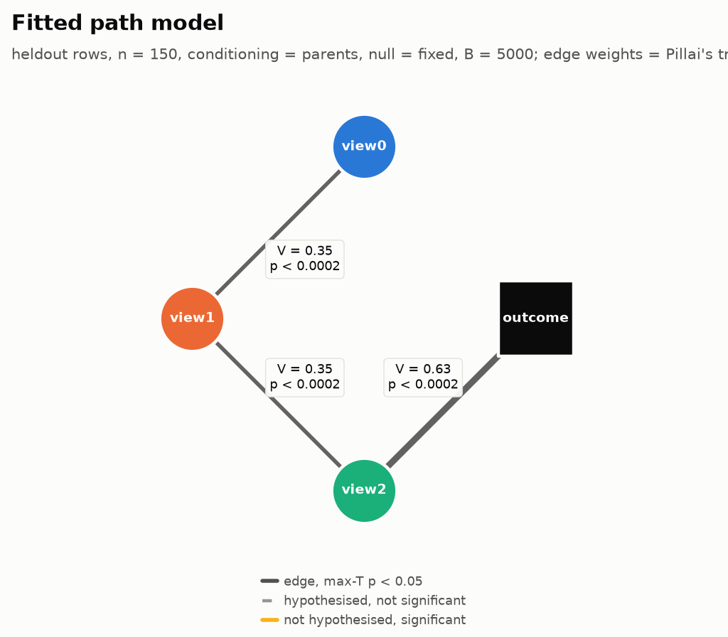

| a | b | present | diagnostic | pillai | rv | p_perm | p_maxt | p_holm | q_bh | p_refit | p_refit_holm | ci_low | ci_high | ci_refit_low | ci_refit_high |
| --- | --- | --- | --- | --- | --- | --- | --- | --- | --- | --- | --- | --- | --- | --- | --- |
| view0 | view1 | True | False | 0.3451 | 0.3321 | 0.0002 | 0.0002 | 0.0012 | 0.0004 | None | None | 0.2833 | 0.4215 | None | None |
| view0 | view2 | False | False | 0.01729 | -0.007507 | 0.5959 | 0.9856 | 0.595881 | 0.595881 | None | None | 0.01282 | 0.07311 | None | None |
| view0 | outcome | False | False | 0.02909 | 0.005798 | 0.2523 | 0.7441 | 0.504699 | 0.302819 | None | None | 0.007624 | 0.1232 | None | None |
| view1 | view2 | True | False | 0.3462 | 0.3309 | 0.0002 | 0.0002 | 0.0012 | 0.0004 | None | None | 0.2894 | 0.421 | None | None |
| view1 | outcome | False | False | 0.05083 | 0.0195 | 0.06559 | 0.1884 | 0.196761 | 0.09838 | None | None | 0.01024 | 0.1643 | None | None |
| view2 | outcome | True | False | 0.6333 | 0.3799 | 0.0002 | 0.0002 | 0.0012 | 0.0004 | None | None | 0.5325 | 0.7297 | None | None |

The same edges under pairwise conditioning (nuisance only). The absent view0 - view2 edge is strong pairwise and weak given view1: the chain's conditional independence, attenuated by measurement error in view1's scores.

| a | b | present | diagnostic | pillai | rv | p_perm | p_maxt | p_holm | q_bh | p_refit | p_refit_holm | ci_low | ci_high | ci_refit_low | ci_refit_high |
| --- | --- | --- | --- | --- | --- | --- | --- | --- | --- | --- | --- | --- | --- | --- | --- |
| view0 | view1 | True | False | 0.4795 | 0.4702 | 0.0002 | 0.0002 | 0.0012 | 0.0002 | None | None | 0.4222 | 0.5427 | None | None |
| view0 | view2 | False | False | 0.2168 | 0.1982 | 0.0002 | 0.0002 | 0.0012 | 0.0002 | None | None | 0.1665 | 0.2898 | None | None |
| view0 | outcome | False | False | 0.1711 | 0.08755 | 0.0002 | 0.0002 | 0.0012 | 0.0002 | None | None | 0.09202 | 0.2973 | None | None |
| view1 | view2 | True | False | 0.5009 | 0.4812 | 0.0002 | 0.0002 | 0.0012 | 0.0002 | None | None | 0.4479 | 0.5641 | None | None |
| view1 | outcome | False | False | 0.2911 | 0.1655 | 0.0002 | 0.0002 | 0.0012 | 0.0002 | None | None | 0.168 | 0.448 | None | None |
| view2 | outcome | True | False | 0.7315 | 0.4287 | 0.0002 | 0.0002 | 0.0012 | 0.0002 | None | None | 0.6487 | 0.8037 | None | None |

## 2. Per-component partial correlations

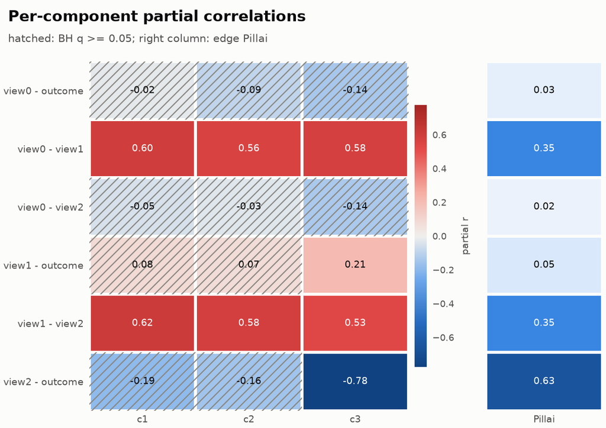

| a | b | component | r | beta | diagnostic | p_perm | p_maxt | p_holm | q_bh | ci_low | ci_high | beta_ci_low | beta_ci_high |
| --- | --- | --- | --- | --- | --- | --- | --- | --- | --- | --- | --- | --- | --- |
| view0 | view1 | 0 | 0.5954 | 0.4653 | False | 0.0002 | 0.0002 | 0.003599 | 0.000514 | 0.4823 | 0.6961 | 0.3649 | 0.576 |
| view0 | view1 | 1 | 0.5631 | 0.4461 | False | 0.0002 | 0.0002 | 0.003599 | 0.000514 | 0.4407 | 0.6649 | 0.3439 | 0.5432 |
| view0 | view1 | 2 | 0.5765 | 0.4635 | False | 0.0002 | 0.0002 | 0.003599 | 0.000514 | 0.4732 | 0.6686 | 0.3573 | 0.5729 |
| view0 | view2 | 0 | -0.0537 | -0.05015 | False | 0.5051 | 1 | 1.0 | 0.568236 | -0.2205 | 0.103 | -0.2203 | 0.09604 |
| view0 | view2 | 1 | -0.035 | -0.03304 | False | 0.6831 | 1 | 1.0 | 0.723244 | -0.2125 | 0.1388 | -0.2093 | 0.1303 |
| view0 | view2 | 2 | -0.1372 | -0.08654 | False | 0.102 | 0.8262 | 0.724655 | 0.152969 | -0.2918 | 0.0292 | -0.1823 | 0.01881 |
| view0 | outcome | 0 | -0.02326 | -0.01688 | False | 0.778 | 1 | 1.0 | 0.778044 | -0.2037 | 0.1641 | -0.1517 | 0.119 |
| view0 | outcome | 1 | -0.09437 | -0.06567 | False | 0.2595 | 0.9918 | 1.0 | 0.359374 | -0.2575 | 0.07248 | -0.1818 | 0.05063 |
| view0 | outcome | 2 | -0.1436 | -0.1034 | False | 0.09058 | 0.7772 | 0.724655 | 0.148225 | -0.2994 | 0.02202 | -0.2179 | 0.01618 |
| view1 | view2 | 0 | 0.6168 | 0.7396 | False | 0.0002 | 0.0002 | 0.003599 | 0.000514 | 0.5271 | 0.6967 | 0.605 | 0.8917 |
| view1 | view2 | 1 | 0.5848 | 0.6957 | False | 0.0002 | 0.0002 | 0.003599 | 0.000514 | 0.4932 | 0.6686 | 0.5519 | 0.8609 |
| view1 | view2 | 2 | 0.5314 | 0.4278 | False | 0.0002 | 0.0002 | 0.003599 | 0.000514 | 0.3922 | 0.6494 | 0.3053 | 0.5466 |
| view1 | outcome | 0 | 0.08233 | 0.07638 | False | 0.3411 | 0.9974 | 1.0 | 0.438598 | -0.09091 | 0.2373 | -0.08118 | 0.2322 |
| view1 | outcome | 1 | 0.07417 | 0.06581 | False | 0.3823 | 0.9998 | 1.0 | 0.458788 | -0.08386 | 0.2458 | -0.0753 | 0.2216 |
| view1 | outcome | 2 | 0.2065 | 0.1912 | False | 0.016 | 0.2018 | 0.175965 | 0.035993 | 0.02987 | 0.3691 | 0.02919 | 0.3419 |
| view2 | outcome | 0 | -0.1907 | -0.2388 | False | 0.02639 | 0.3107 | 0.263947 | 0.052789 | -0.3355 | -0.02757 | -0.4108 | -0.03437 |
| view2 | outcome | 1 | -0.1566 | -0.188 | False | 0.05519 | 0.6421 | 0.496701 | 0.09934 | -0.3223 | 0.001044 | -0.3921 | 0.001388 |
| view2 | outcome | 2 | -0.7751 | -0.9202 | False | 0.0002 | 0.0002 | 0.003599 | 0.000514 | -0.8349 | -0.6956 | -1.051 | -0.7818 |

## 3. Graph comparison (measurement model fixed)

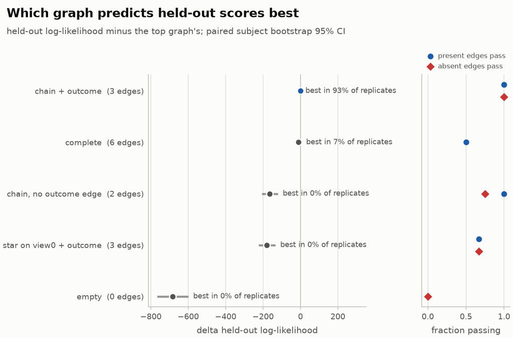

| graph | n_edges | heldout_loglik | n_params | bic | present_pass | absent_pass | max_absent_p | delta_vs_top | ci_low | ci_high | best_fraction |
| --- | --- | --- | --- | --- | --- | --- | --- | --- | --- | --- | --- |
| chain + outcome | 3 | -1445 | 61 | 6848 | 1 | 1 | 0.1349 | 0 | 0 | 0 | 0.9275 |
| star on view0 + outcome | 3 | -1625 | 61 | 7516 | 0.6667 | 0.6667 | 0.000999 | -180.4 | -224.2 | -134.5 | 0 |
| complete | 6 | -1455 | 76 | 6892 | 0.5 |  |  | -10.69 | -24.05 | 3.643 | 0.0725 |
| empty | 0 | -2129 | 40 | 1.017e+04 |  | 0 | 0.000999 | -684.6 | -767.3 | -600.1 | 0 |
| chain, no outcome edge | 2 | -1609 | 58 | 7669 | 1 | 0.75 | 0.000999 | -164.4 | -205.7 | -121.1 | 0 |

Best (fewest edges whose paired delta CI against the top includes 0, plan F1): **chain + outcome**; top by held-out log-likelihood: **chain + outcome**. BIC counts each undirected edge once (plan F4).

## 4. Null distributions

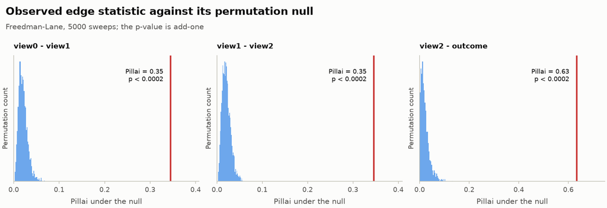

## 5. Prediction through the graph

With view1 missing, its scores predicted from view0 and view2 reach R² = 0.683 against the scores computed from the real view1. The outcome predicted from its graph parents (all views present) reaches held-out R² = 0.734.

## 6. Feature contributions to edge view0 - view1

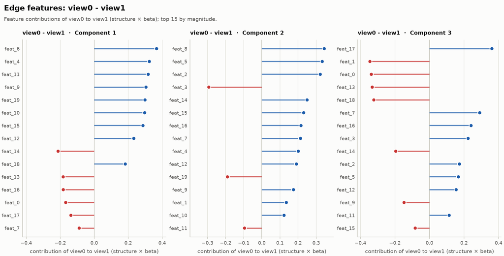